# In this project we are going to do the exploratory data analysis and are going to make a suitable machine learning model of a dataset containg data about A used car dealership specializes in selling cars from various brands.And going to predict prize on the basis the car condition based on the different features.

The objecctive of the project is to identify the factor's contribution to the prize of the used car.

in order to make our analysis we are going to import some python library's

```python
import numpy as np
```

```python
import pandas as pd
```

```python
import matplotlib.pyplot as plt
```

```python
import seaborn as sns
```

Reading the data from the source and creating a dataframe

```python
df=pd.read_csv(r"C:\Users\pk859\Downloads\CarDataSet.csv")
```

```python
df
```

|  | Unnamed: 0 | Name | Location | Year | Kilometers_Driven | Fuel_Type | Transmission | Owner_Type | Mileage | Engine | Power | Seats | New_Price | Price |
| --- | --- | --- | --- | --- | --- | --- | --- | --- | --- | --- | --- | --- | --- | --- |
| 0 | 0 | Maruti Wagon R LXI CNG | Mumbai | 2010 | 72000 | CNG | Manual | First | 26.6 km/kg | 998 CC | 58.16 bhp | 5.0 | NaN | 1.75 |
| 1 | 1 | Hyundai Creta 1.6 CRDi SX Option | Pune | 2015 | 41000 | Diesel | Manual | First | 19.67 kmpl | 1582 CC | 126.2 bhp | 5.0 | NaN | 12.50 |
| 2 | 2 | Honda Jazz V | Chennai | 2011 | 46000 | Petrol | Manual | First | 18.2 kmpl | 1199 CC | 88.7 bhp | 5.0 | 8.61 Lakh | 4.50 |
| 3 | 3 | Maruti Ertiga VDI | Chennai | 2012 | 87000 | Diesel | Manual | First | 20.77 kmpl | 1248 CC | 88.76 bhp | 7.0 | NaN | 6.00 |
| 4 | 4 | Audi A4 New 2.0 TDI Multitronic | Coimbatore | 2013 | 40670 | Diesel | Automatic | Second | 15.2 kmpl | 1968 CC | 140.8 bhp | 5.0 | NaN | 17.74 |
| ... | ... | ... | ... | ... | ... | ... | ... | ... | ... | ... | ... | ... | ... | ... |
| 7248 | 1229 | Volkswagen Vento Diesel Trendline | Hyderabad | 2011 | 89411 | Diesel | Manual | First | 20.54 kmpl | 1598 CC | 103.6 bhp | 5.0 | NaN | NaN |
| 7249 | 1230 | Volkswagen Polo GT TSI | Mumbai | 2015 | 59000 | Petrol | Automatic | First | 17.21 kmpl | 1197 CC | 103.6 bhp | 5.0 | NaN | NaN |
| 7250 | 1231 | Nissan Micra Diesel XV | Kolkata | 2012 | 28000 | Diesel | Manual | First | 23.08 kmpl | 1461 CC | 63.1 bhp | 5.0 | NaN | NaN |
| 7251 | 1232 | Volkswagen Polo GT TSI | Pune | 2013 | 52262 | Petrol | Automatic | Third | 17.2 kmpl | 1197 CC | 103.6 bhp | 5.0 | NaN | NaN |
| 7252 | 1233 | Mercedes-Benz E-Class 2009-2013 E 220 CDI Avan... | Kochi | 2014 | 72443 | Diesel | Automatic | First | 10.0 kmpl | 2148 CC | 170 bhp | 5.0 | NaN | NaN |

7253 rows × 14 columns

# printing the top 5 rows from the df dataset

```python
df.head(5)
```

|  | Unnamed: 0 | Name | Location | Year | Kilometers_Driven | Fuel_Type | Transmission | Owner_Type | Mileage | Engine | Power | Seats | New_Price | Price |
| --- | --- | --- | --- | --- | --- | --- | --- | --- | --- | --- | --- | --- | --- | --- |
| 0 | 0 | Maruti Wagon R LXI CNG | Mumbai | 2010 | 72000 | CNG | Manual | First | 26.6 km/kg | 998 CC | 58.16 bhp | 5.0 | NaN | 1.75 |
| 1 | 1 | Hyundai Creta 1.6 CRDi SX Option | Pune | 2015 | 41000 | Diesel | Manual | First | 19.67 kmpl | 1582 CC | 126.2 bhp | 5.0 | NaN | 12.50 |
| 2 | 2 | Honda Jazz V | Chennai | 2011 | 46000 | Petrol | Manual | First | 18.2 kmpl | 1199 CC | 88.7 bhp | 5.0 | 8.61 Lakh | 4.50 |
| 3 | 3 | Maruti Ertiga VDI | Chennai | 2012 | 87000 | Diesel | Manual | First | 20.77 kmpl | 1248 CC | 88.76 bhp | 7.0 | NaN | 6.00 |
| 4 | 4 | Audi A4 New 2.0 TDI Multitronic | Coimbatore | 2013 | 40670 | Diesel | Automatic | Second | 15.2 kmpl | 1968 CC | 140.8 bhp | 5.0 | NaN | 17.74 |

```python
#on inspection above dataset we can clearely see that our target feature is Price
```

target variable: the column named "Price" which contains the price of the refurbished or the resseling price

for knowing how big is our dataset we are going to inspect the data by the shape function

```python
df.shape
```

```
(7253, 14)
```

our dataset contains 7253 rows and 14 columns

```python
df.sample(10)
```

|  | Unnamed: 0 | Name | Location | Year | Kilometers_Driven | Fuel_Type | Transmission | Owner_Type | Mileage | Engine | Power | Seats | New_Price | Price |
| --- | --- | --- | --- | --- | --- | --- | --- | --- | --- | --- | --- | --- | --- | --- |
| 402 | 402 | Maruti Alto LX | Jaipur | 2010 | 125000 | Petrol | Manual | First | 19.7 kmpl | 796 CC | 46.3 bhp | 5.0 | NaN | 0.92 |
| 341 | 341 | Toyota Corolla H4 | Kolkata | 2008 | 80000 | Petrol | Automatic | First | 11.3 kmpl | 1794 CC | 125 bhp | 5.0 | NaN | 2.80 |
| 4431 | 4431 | Hyundai EON Era Plus | Kochi | 2013 | 57759 | Petrol | Manual | First | 21.1 kmpl | 814 CC | 55.2 bhp | 5.0 | NaN | 3.84 |
| 3374 | 3374 | Renault Duster 110PS Diesel RxZ AMT | Jaipur | 2016 | 68163 | Diesel | Automatic | First | 19.6 kmpl | 1461 CC | 108.45 bhp | 5.0 | 14.11 Lakh | 8.90 |
| 2579 | 2579 | Hyundai Santro Xing XG eRLX Euro III | Mumbai | 2006 | 50888 | Petrol | Manual | First | 17.0 kmpl | 1086 CC | null bhp | 5.0 | NaN | 1.15 |
| 2295 | 2295 | Ford Figo 2015-2019 1.2P Trend MT | Coimbatore | 2017 | 39419 | Petrol | Manual | First | 18.16 kmpl | 1196 CC | 86.8 bhp | 5.0 | NaN | 4.95 |
| 5652 | 5652 | Toyota Fortuner 4x4 MT | Jaipur | 2014 | 122000 | Diesel | Manual | Second | 12.55 kmpl | 2982 CC | 168.5 bhp | 7.0 | NaN | 16.00 |
| 714 | 714 | Maruti Dzire AMT ZXI Plus | Hyderabad | 2017 | 13000 | Petrol | Automatic | First | 22.0 kmpl | 1197 CC | 81.80 bhp | 5.0 | 10.34 Lakh | 8.50 |
| 1761 | 1761 | Hyundai Grand i10 Magna | Jaipur | 2014 | 42355 | Petrol | Manual | First | 18.9 kmpl | 1197 CC | 82 bhp | 5.0 | NaN | 4.00 |
| 6476 | 457 | Hyundai Elantra GT | Hyderabad | 2006 | 88000 | Petrol | Manual | First | 13.0 kmpl | 1795 CC | 127 bhp | 5.0 | NaN | NaN |

for knowing how our data look like we are going to inspect rambomely picked up 10 rows.

we are going to use info function for knowing the data type of columns.

```python
df.info()
```

```
<class 'pandas.core.frame.DataFrame'>
RangeIndex: 7253 entries, 0 to 7252
Data columns (total 14 columns):
 #   Column             Non-Null Count  Dtype
---  ------             --------------  -----
 0   Unnamed: 0         7253 non-null   int64
 1   Name               7253 non-null   object
 2   Location           7253 non-null   object
 3   Year               7253 non-null   int64
 4   Kilometers_Driven  7253 non-null   int64
 5   Fuel_Type          7253 non-null   object
 6   Transmission       7253 non-null   object
 7   Owner_Type         7253 non-null   object
 8   Mileage            7251 non-null   object
 9   Engine             7207 non-null   object
 10  Power              7207 non-null   object
 11  Seats              7200 non-null   float64
 12  New_Price          1006 non-null   object
 13  Price              6019 non-null   float64
dtypes: float64(2), int64(3), object(9)
memory usage: 793.4+ KB
```

apart from the target, the rest of the 13 columns are the features and they can be further used for our analysis.

```python
df.isnull().sum()
```

```
Unnamed: 0              0
Name                    0
Location                0
Year                    0
Kilometers_Driven       0
Fuel_Type               0
Transmission            0
Owner_Type              0
Mileage                 2
Engine                 46
Power                  46
Seats                  53
New_Price            6247
Price                1234
dtype: int64
```

on checking for null values we got 2 null values in milage feature, 46 null values in the Engine feature 46 null values in the power feature, 53 null values in the seats feature , 6247 null values in the New_Price and 1234 null values in the price feature. but new_price column need a special attention.

```python
df.describe()                # creating descriptive summary of the numerical features
```

|  | Unnamed: 0 | Year | Kilometers_Driven | Seats | Price |
| --- | --- | --- | --- | --- | --- |
| count | 7253.000000 | 7253.000000 | 7.253000e+03 | 7200.000000 | 6019.000000 |
| mean | 2601.948435 | 2013.365366 | 5.869906e+04 | 5.279722 | 9.479468 |
| std | 1826.365869 | 3.254421 | 8.442772e+04 | 0.811660 | 11.187917 |
| min | 0.000000 | 1996.000000 | 1.710000e+02 | 0.000000 | 0.440000 |
| 25% | 906.000000 | 2011.000000 | 3.400000e+04 | 5.000000 | 3.500000 |
| 50% | 2392.000000 | 2014.000000 | 5.341600e+04 | 5.000000 | 5.640000 |
| 75% | 4205.000000 | 2016.000000 | 7.300000e+04 | 5.000000 | 9.950000 |
| max | 6018.000000 | 2019.000000 | 6.500000e+06 | 10.000000 | 160.000000 |

```python
df.rename(columns = {"Unnamed: 0":"car_id"}, inplace = True)   #changed the column name from unamed to car_id for consistancy of data
```

```python
df1=df.copy()
```

copied our original dataset to the new dataset so that in order to transform our data for analysis our original data remains untouched.

```python
#changing desired datatype into numeric
```

```python
df1["Mileage"].replace({"km/kg":"kmpl"})
```

```
0       26.6 km/kg
1       19.67 kmpl
2        18.2 kmpl
3       20.77 kmpl
4        15.2 kmpl
           ...
7248    20.54 kmpl
7249    17.21 kmpl
7250    23.08 kmpl
7251     17.2 kmpl
7252     10.0 kmpl
Name: Mileage, Length: 7253, dtype: object
```

```python
for i in df.columns:
    print(f"unnique{i}'s count:{df1[i].nunique()}")
    print(f"{df1[i].unique()}\n")
```

[output not shown]

[output cut: 273 more lines]

[output not shown]

```python
df1["Mileage"]=df1["Mileage"].str.replace("[^\d\.]", " ").astype("float64")
```

```python
df1["Engine"]=df1["Engine"].str.replace("[^\d\.]", " ").astype("float64")
```

```python
#df1["Power"]=df1["Power"].str.replace("[^\d\.]","").astype("float64")
```

```python
df1.info()
```

```
<class 'pandas.core.frame.DataFrame'>
RangeIndex: 7253 entries, 0 to 7252
Data columns (total 14 columns):
 #   Column             Non-Null Count  Dtype
---  ------             --------------  -----
 0   car_id             7253 non-null   int64
 1   Name               7253 non-null   object
 2   Location           7253 non-null   object
 3   Year               7253 non-null   int64
 4   Kilometers_Driven  7253 non-null   int64
 5   Fuel_Type          7253 non-null   object
 6   Transmission       7253 non-null   object
 7   Owner_Type         7253 non-null   object
 8   Mileage            7251 non-null   float64
 9   Engine             7207 non-null   float64
 10  Power              7207 non-null   object
 11  Seats              7200 non-null   float64
 12  New_Price          1006 non-null   object
 13  Price              6019 non-null   float64
dtypes: float64(4), int64(3), object(7)
memory usage: 793.4+ KB
```

so,here we can see that our milage column has changed to float type by using as type function

```python
df1.duplicated().sum()
```

```
0
```

so, we have 0 duplicate value in our dataset

```python
df1.corr()
```

|  | car_id | Year | Kilometers_Driven | Mileage | Engine | Seats | Price |
| --- | --- | --- | --- | --- | --- | --- | --- |
| car_id | 1.000000 | 0.000366 | -0.007550 | 0.017937 | 0.004862 | -0.011027 | -0.020275 |
| Year | 0.000366 | 1.000000 | -0.187859 | 0.322463 | -0.054693 | 0.008216 | 0.305327 |
| Kilometers_Driven | -0.007550 | -0.187859 | 1.000000 | -0.069122 | 0.094818 | 0.090221 | -0.011493 |
| Mileage | 0.017937 | 0.322463 | -0.069122 | 1.000000 | -0.593569 | -0.310632 | -0.306593 |
| Engine | 0.004862 | -0.054693 | 0.094818 | -0.593569 | 1.000000 | 0.399262 | 0.658354 |
| Seats | -0.011027 | 0.008216 | 0.090221 | -0.310632 | 0.399262 | 1.000000 | 0.052225 |
| Price | -0.020275 | 0.305327 | -0.011493 | -0.306593 | 0.658354 | 0.052225 | 1.000000 |

```python
pip install pandas-profiling
```

```python
#from pandas_profiling import Profile_Report
#prof = ProfileReport(df)
#prof.to_file(output_file = "output.html")
```

[figure not shown]

```python
sns.relplot(x="Engine",y="Price",data=df)
```

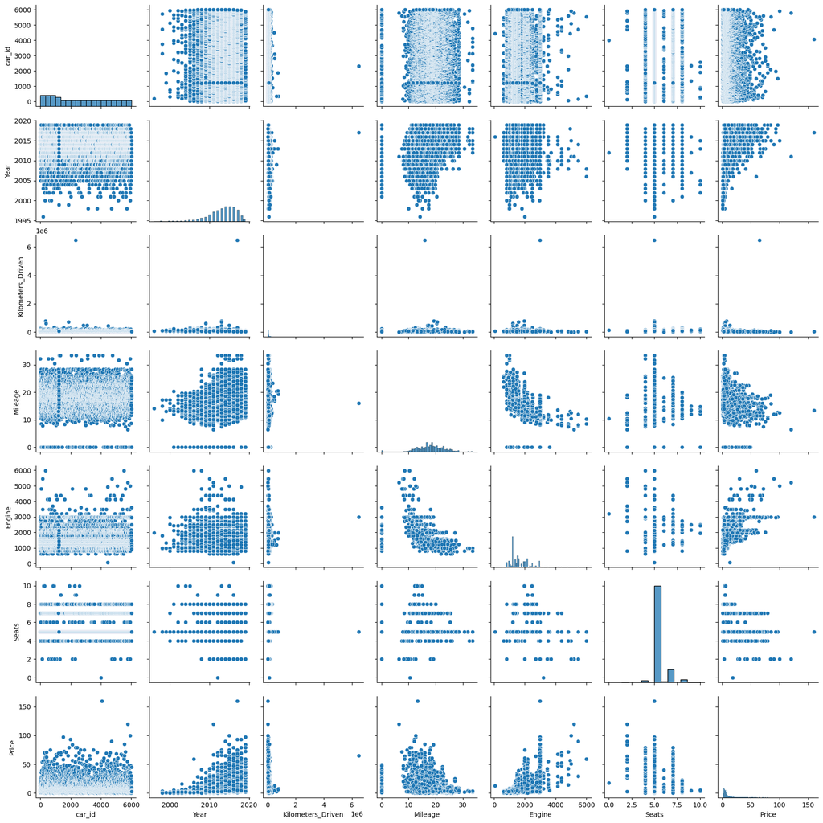

```python
sns.pairplot(df1)
```

```python
#sns.scatterplot(x="Price",y="Engine",hue="Owner_Type",data=df1)
```

now we are going to deal with the null values in the columns.

we got 1234 null values in our target column i.e price now we are going to replace it with the mean value of the price column.

```python
df1["Price"].mean()
```

```
9.47946835022429
```

```python
df1["Price"].fillna(9.47, inplace= True)
```

```python
df1["Seats"].mean()        #we are going to replace with seats data with mean value.
```

```
5.279722222222222
```

```python
df1["Seats"].fillna(5.2, inplace= True)
```

```python
df1.info()
```

```
<class 'pandas.core.frame.DataFrame'>
RangeIndex: 7253 entries, 0 to 7252
Data columns (total 14 columns):
 #   Column             Non-Null Count  Dtype
---  ------             --------------  -----
 0   car_id             7253 non-null   int64
 1   Name               7253 non-null   object
 2   Location           7253 non-null   object
 3   Year               7253 non-null   int64
 4   Kilometers_Driven  7253 non-null   int64
 5   Fuel_Type          7253 non-null   object
 6   Transmission       7253 non-null   object
 7   Owner_Type         7253 non-null   object
 8   Mileage            7251 non-null   float64
 9   Engine             7207 non-null   float64
 10  Power              7207 non-null   object
 11  Seats              7253 non-null   float64
 12  New_Price          1006 non-null   object
 13  Price              7253 non-null   float64
dtypes: float64(4), int64(3), object(7)
memory usage: 793.4+ KB
```

```python
df1["Engine"].mean()
```

```
1616.5734702372692
```

```python
df1.isnull().sum()
```

```
car_id                  0
Name                    0
Location                0
Year                    0
Kilometers_Driven       0
Fuel_Type               0
Transmission            0
Owner_Type              0
Mileage                 2
Engine                 46
Power                  46
Seats                   0
New_Price            6247
Price                   0
dtype: int64
```

```python
df1["Engine"].fillna(1616.57, inplace= True)     #same with the engine column
```

```python
df1.info()
```

```
<class 'pandas.core.frame.DataFrame'>
RangeIndex: 7253 entries, 0 to 7252
Data columns (total 14 columns):
 #   Column             Non-Null Count  Dtype
---  ------             --------------  -----
 0   car_id             7253 non-null   int64
 1   Name               7253 non-null   object
 2   Location           7253 non-null   object
 3   Year               7253 non-null   int64
 4   Kilometers_Driven  7253 non-null   int64
 5   Fuel_Type          7253 non-null   object
 6   Transmission       7253 non-null   object
 7   Owner_Type         7253 non-null   object
 8   Mileage            7251 non-null   float64
 9   Engine             7253 non-null   float64
 10  Power              7207 non-null   object
 11  Seats              7253 non-null   float64
 12  New_Price          1006 non-null   object
 13  Price              7253 non-null   float64
dtypes: float64(4), int64(3), object(7)
memory usage: 793.4+ KB
```

```python
df1["Mileage"].mean()
```

```
18.141580471659083
```

```python
df1["Mileage"].fillna(18.14, inplace= True)
```

```python
df1.info()
```

```
<class 'pandas.core.frame.DataFrame'>
RangeIndex: 7253 entries, 0 to 7252
Data columns (total 14 columns):
 #   Column             Non-Null Count  Dtype
---  ------             --------------  -----
 0   car_id             7253 non-null   int64
 1   Name               7253 non-null   object
 2   Location           7253 non-null   object
 3   Year               7253 non-null   int64
 4   Kilometers_Driven  7253 non-null   int64
 5   Fuel_Type          7253 non-null   object
 6   Transmission       7253 non-null   object
 7   Owner_Type         7253 non-null   object
 8   Mileage            7253 non-null   float64
 9   Engine             7253 non-null   float64
 10  Power              7207 non-null   object
 11  Seats              7253 non-null   float64
 12  New_Price          1006 non-null   object
 13  Price              7253 non-null   float64
dtypes: float64(4), int64(3), object(7)
memory usage: 793.4+ KB
```

now we are done with null values in our desired features in which we are going to perform our future analysis.

for the sake of data consistancy and for our analysis we are going to replace the 'First' with 1 ,'Second' with 2 ,'Fourth & Above' with 4, 'Third'with 3 in the owner_type feature. so that we can perform our analysis smoothly and for our further data drill in we need to convert this column into integer also.

```python
df1["Owner_Type"].nunique()  #total unique values in the owner_type column.
```

```
4
```

```python
df1["Owner_Type"].replace({'First':1, 'Second':2, 'Fourth & Above':4, 'Third':3}, inplace=True)
```

for the sake of data consistancy and for our analysis we are going to replace the "manual" with 0 and "AUTOMATIC" with 1 in the TRANSMISSION column. so that we can perform our analysis smoothly and for our further data drill in we need to convert this column into integer also.

```python
df1["Transmission"].nunique()               #total unique values in the transmission column.
```

```
2
```

```python
df1["Transmission"].replace({'Manual':0, 'Automatic':1}, inplace= True)
```

for the sake of data consistancy and for our analysis we are going to replace the 'CNG':1, 'Diesel':2, 'Petrol':3, 'LPG':4, 'Electric':5 in the fuel type column. so that we can perform our analysis smoothly and for our further data drill in we need to convert this column into integer also.

```python
df1["Fuel_Type"].nunique()
```

```
5
```

```python
df1["Fuel_Type"].replace({'CNG':1, 'Diesel':2, 'Petrol':3, 'LPG':4, 'Electric':5}, inplace = True)
```

```python
df1.info()
```

```
<class 'pandas.core.frame.DataFrame'>
RangeIndex: 7253 entries, 0 to 7252
Data columns (total 14 columns):
 #   Column             Non-Null Count  Dtype
---  ------             --------------  -----
 0   car_id             7253 non-null   int64
 1   Name               7253 non-null   object
 2   Location           7253 non-null   object
 3   Year               7253 non-null   int64
 4   Kilometers_Driven  7253 non-null   int64
 5   Fuel_Type          7253 non-null   int64
 6   Transmission       7253 non-null   int64
 7   Owner_Type         7253 non-null   int64
 8   Mileage            7253 non-null   float64
 9   Engine             7253 non-null   float64
 10  Power              7207 non-null   object
 11  Seats              7253 non-null   float64
 12  New_Price          1006 non-null   object
 13  Price              7253 non-null   float64
dtypes: float64(4), int64(6), object(4)
memory usage: 793.4+ KB
```

# Univariate Analysis.

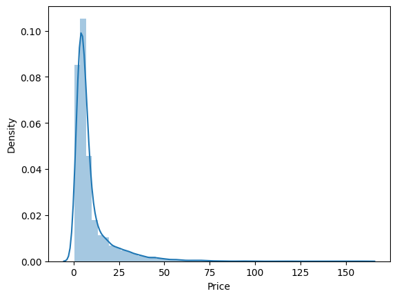

```python
sns.distplot(df["Price"])
plt.show()
```

so the distplot of price is cleared shifted in the 0 to 25

distplot:= a distplot or a distribution plot, depicts the variation in the data distribution, it represents the overall distribution of the continuous data variables.

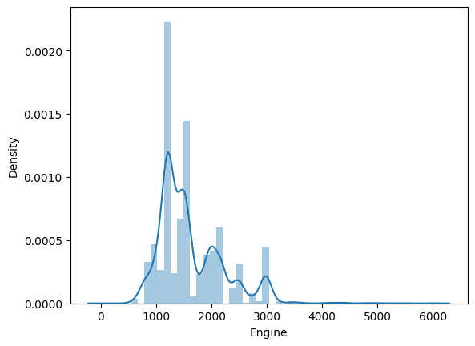

```python
sns.distplot(df1["Engine"])
```

so we have more number of engine in between 1000 cc to 2000 cc.

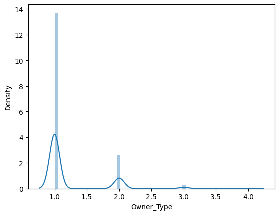

```python
sns.distplot(df1["Owner_Type"])
```

on lookin this distplot we can say that we have mejority of first hand car. and we also have second hand cars but we have a few third hand and fouth and above hand cars.

```python
df1
```

|  | car_id | Name | Location | Year | Kilometers_Driven | Fuel_Type | Transmission | Owner_Type | Mileage | Engine | Power | Seats | New_Price | Price |
| --- | --- | --- | --- | --- | --- | --- | --- | --- | --- | --- | --- | --- | --- | --- |
| 0 | 0 | Maruti Wagon R LXI CNG | Mumbai | 2010 | 72000 | 1 | 0 | 1 | 26.60 | 998.0 | 58.16 bhp | 5.0 | NaN | 1.75 |
| 1 | 1 | Hyundai Creta 1.6 CRDi SX Option | Pune | 2015 | 41000 | 2 | 0 | 1 | 19.67 | 1582.0 | 126.2 bhp | 5.0 | NaN | 12.50 |
| 2 | 2 | Honda Jazz V | Chennai | 2011 | 46000 | 3 | 0 | 1 | 18.20 | 1199.0 | 88.7 bhp | 5.0 | 8.61 Lakh | 4.50 |
| 3 | 3 | Maruti Ertiga VDI | Chennai | 2012 | 87000 | 2 | 0 | 1 | 20.77 | 1248.0 | 88.76 bhp | 7.0 | NaN | 6.00 |
| 4 | 4 | Audi A4 New 2.0 TDI Multitronic | Coimbatore | 2013 | 40670 | 2 | 1 | 2 | 15.20 | 1968.0 | 140.8 bhp | 5.0 | NaN | 17.74 |
| ... | ... | ... | ... | ... | ... | ... | ... | ... | ... | ... | ... | ... | ... | ... |
| 7248 | 1229 | Volkswagen Vento Diesel Trendline | Hyderabad | 2011 | 89411 | 2 | 0 | 1 | 20.54 | 1598.0 | 103.6 bhp | 5.0 | NaN | 9.47 |
| 7249 | 1230 | Volkswagen Polo GT TSI | Mumbai | 2015 | 59000 | 3 | 1 | 1 | 17.21 | 1197.0 | 103.6 bhp | 5.0 | NaN | 9.47 |
| 7250 | 1231 | Nissan Micra Diesel XV | Kolkata | 2012 | 28000 | 2 | 0 | 1 | 23.08 | 1461.0 | 63.1 bhp | 5.0 | NaN | 9.47 |
| 7251 | 1232 | Volkswagen Polo GT TSI | Pune | 2013 | 52262 | 3 | 1 | 3 | 17.20 | 1197.0 | 103.6 bhp | 5.0 | NaN | 9.47 |
| 7252 | 1233 | Mercedes-Benz E-Class 2009-2013 E 220 CDI Avan... | Kochi | 2014 | 72443 | 2 | 1 | 1 | 10.00 | 2148.0 | 170 bhp | 5.0 | NaN | 9.47 |

7253 rows × 14 columns

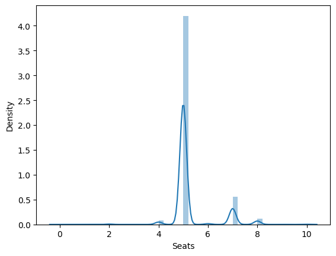

```python
sns.distplot(df["Seats"])
```

so, we have a large number of cars as a 5 seater.

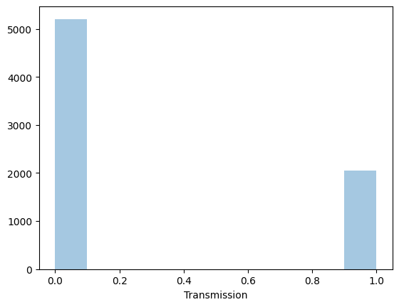

```python
sns.distplot(df1["Transmission"],kde=False)
```

so here we clearly conclude that we have more maunual cars as compared to automatic

```python
df1.info()
```

```
<class 'pandas.core.frame.DataFrame'>
RangeIndex: 7253 entries, 0 to 7252
Data columns (total 14 columns):
 #   Column             Non-Null Count  Dtype
---  ------             --------------  -----
 0   car_id             7253 non-null   int64
 1   Name               7253 non-null   object
 2   Location           7253 non-null   object
 3   Year               7253 non-null   int64
 4   Kilometers_Driven  7253 non-null   int64
 5   Fuel_Type          7253 non-null   int64
 6   Transmission       7253 non-null   int64
 7   Owner_Type         7253 non-null   int64
 8   Mileage            7253 non-null   float64
 9   Engine             7253 non-null   float64
 10  Power              7207 non-null   object
 11  Seats              7253 non-null   float64
 12  New_Price          1006 non-null   object
 13  Price              7253 non-null   float64
dtypes: float64(4), int64(6), object(4)
memory usage: 793.4+ KB
```

```python
df1
```

|  | car_id | Name | Location | Year | Kilometers_Driven | Fuel_Type | Transmission | Owner_Type | Mileage | Engine | Power | Seats | New_Price | Price |
| --- | --- | --- | --- | --- | --- | --- | --- | --- | --- | --- | --- | --- | --- | --- |
| 0 | 0 | Maruti Wagon R LXI CNG | Mumbai | 2010 | 72000 | 1 | 0 | 1 | 26.60 | 998.0 | 58.16 bhp | 5.0 | NaN | 1.75 |
| 1 | 1 | Hyundai Creta 1.6 CRDi SX Option | Pune | 2015 | 41000 | 2 | 0 | 1 | 19.67 | 1582.0 | 126.2 bhp | 5.0 | NaN | 12.50 |
| 2 | 2 | Honda Jazz V | Chennai | 2011 | 46000 | 3 | 0 | 1 | 18.20 | 1199.0 | 88.7 bhp | 5.0 | 8.61 Lakh | 4.50 |
| 3 | 3 | Maruti Ertiga VDI | Chennai | 2012 | 87000 | 2 | 0 | 1 | 20.77 | 1248.0 | 88.76 bhp | 7.0 | NaN | 6.00 |
| 4 | 4 | Audi A4 New 2.0 TDI Multitronic | Coimbatore | 2013 | 40670 | 2 | 1 | 2 | 15.20 | 1968.0 | 140.8 bhp | 5.0 | NaN | 17.74 |
| ... | ... | ... | ... | ... | ... | ... | ... | ... | ... | ... | ... | ... | ... | ... |
| 7248 | 1229 | Volkswagen Vento Diesel Trendline | Hyderabad | 2011 | 89411 | 2 | 0 | 1 | 20.54 | 1598.0 | 103.6 bhp | 5.0 | NaN | 9.47 |
| 7249 | 1230 | Volkswagen Polo GT TSI | Mumbai | 2015 | 59000 | 3 | 1 | 1 | 17.21 | 1197.0 | 103.6 bhp | 5.0 | NaN | 9.47 |
| 7250 | 1231 | Nissan Micra Diesel XV | Kolkata | 2012 | 28000 | 2 | 0 | 1 | 23.08 | 1461.0 | 63.1 bhp | 5.0 | NaN | 9.47 |
| 7251 | 1232 | Volkswagen Polo GT TSI | Pune | 2013 | 52262 | 3 | 1 | 3 | 17.20 | 1197.0 | 103.6 bhp | 5.0 | NaN | 9.47 |
| 7252 | 1233 | Mercedes-Benz E-Class 2009-2013 E 220 CDI Avan... | Kochi | 2014 | 72443 | 2 | 1 | 1 | 10.00 | 2148.0 | 170 bhp | 5.0 | NaN | 9.47 |

7253 rows × 14 columns

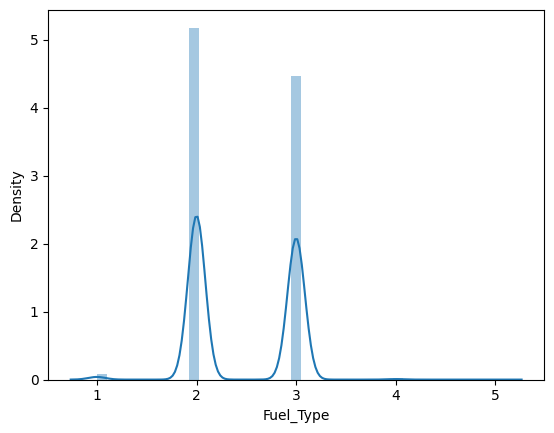

```python
sns.distplot(df1["Fuel_Type"])
```

so we have more number of cars of'Diesel':2 and 'Petrol':3.

```python
df1.info()
```

```
<class 'pandas.core.frame.DataFrame'>
RangeIndex: 7253 entries, 0 to 7252
Data columns (total 14 columns):
 #   Column             Non-Null Count  Dtype
---  ------             --------------  -----
 0   car_id             7253 non-null   int64
 1   Name               7253 non-null   object
 2   Location           7253 non-null   object
 3   Year               7253 non-null   int64
 4   Kilometers_Driven  7253 non-null   int64
 5   Fuel_Type          7253 non-null   int64
 6   Transmission       7253 non-null   int64
 7   Owner_Type         7253 non-null   int64
 8   Mileage            7253 non-null   float64
 9   Engine             7253 non-null   float64
 10  Power              7207 non-null   object
 11  Seats              7253 non-null   float64
 12  New_Price          1006 non-null   object
 13  Price              7253 non-null   float64
dtypes: float64(4), int64(6), object(4)
memory usage: 793.4+ KB
```

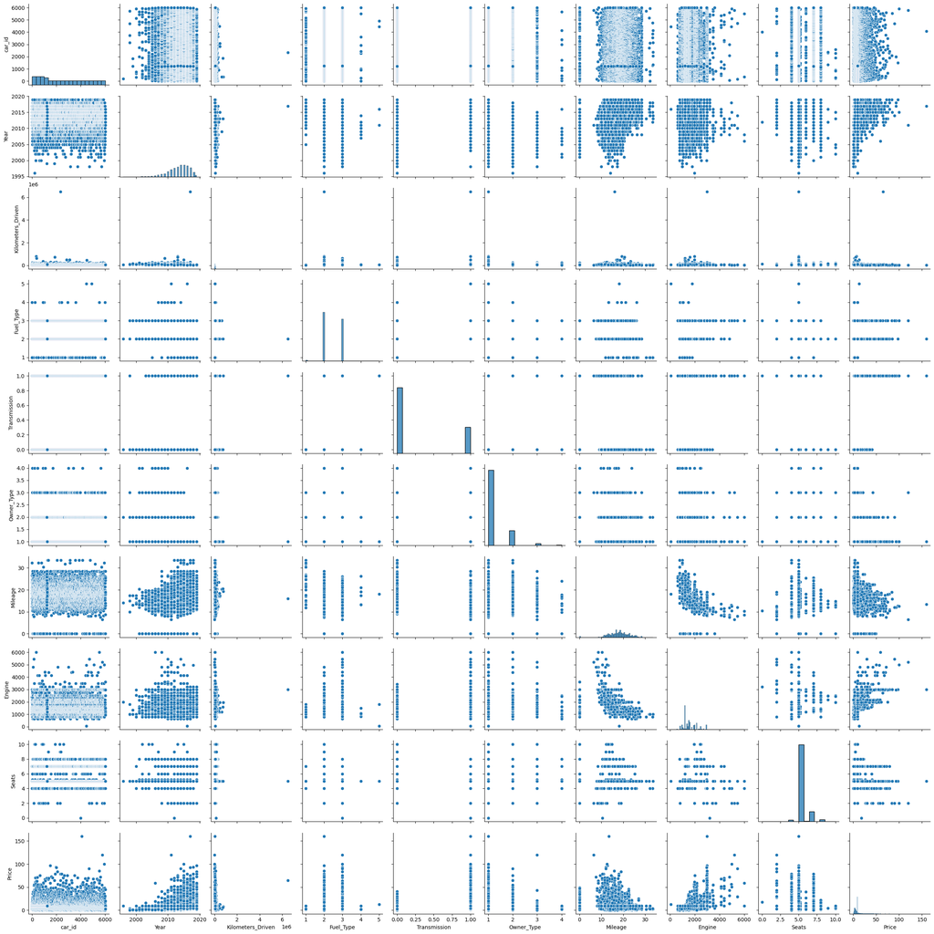

```python
sns.pairplot(df1)
```

```python
df1.corr()
```

|  | car_id | Year | Kilometers_Driven | Fuel_Type | Transmission | Owner_Type | Mileage | Engine | Seats | Price |
| --- | --- | --- | --- | --- | --- | --- | --- | --- | --- | --- |
| car_id | 1.000000 | 0.000366 | -0.007550 | 0.006633 | -0.003142 | -0.001805 | 0.017934 | 0.004850 | -0.010944 | -0.017401 |
| Year | 0.000366 | 1.000000 | -0.187859 | -0.133176 | 0.099975 | -0.395335 | 0.322437 | -0.054233 | 0.008911 | 0.279447 |
| Kilometers_Driven | -0.007550 | -0.187859 | 1.000000 | -0.105110 | -0.031166 | 0.092618 | -0.069122 | 0.094765 | 0.090077 | -0.011317 |
| Fuel_Type | 0.006633 | -0.133176 | -0.105110 | 1.000000 | -0.114515 | 0.050092 | -0.162570 | -0.387032 | -0.282346 | -0.264588 |
| Transmission | -0.003142 | 0.099975 | -0.031166 | -0.114515 | 1.000000 | -0.006718 | -0.327711 | 0.492782 | -0.078980 | 0.535704 |
| Owner_Type | -0.001805 | -0.395335 | 0.092618 | 0.050092 | -0.006718 | 1.000000 | -0.161703 | 0.048895 | 0.016684 | -0.088780 |
| Mileage | 0.017934 | 0.322437 | -0.069122 | -0.162570 | -0.327711 | -0.161703 | 1.000000 | -0.585023 | -0.304619 | -0.280511 |
| Engine | 0.004850 | -0.054233 | 0.094765 | -0.387032 | 0.492782 | 0.048895 | -0.585023 | 1.000000 | 0.399042 | 0.604835 |
| Seats | -0.010944 | 0.008911 | 0.090077 | -0.282346 | -0.078980 | 0.016684 | -0.304619 | 0.399042 | 1.000000 | 0.047501 |
| Price | -0.017401 | 0.279447 | -0.011317 | -0.264588 | 0.535704 | -0.088780 | -0.280511 | 0.604835 | 0.047501 | 1.000000 |

so, we have strong correlation of our car price with transmission and engine part and also have a correlation with year feature. but we have negetive correlation with kilometers_driven, fuel type, and mileage.

# Bi-variate Analysis

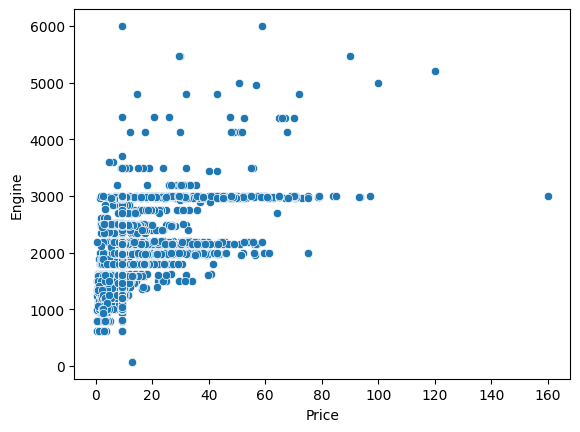

```python
sns.scatterplot(x="Price", y="Engine", data=df1)
```

```python
this is scatterplot between engine and the price features. and we can clearely see that positive correlation between the two.
```

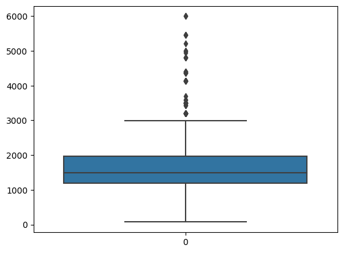

```python
sns.boxplot(df1["Engine"])
```

so we have many outliers which lies withhin the range from 3000 to 6000

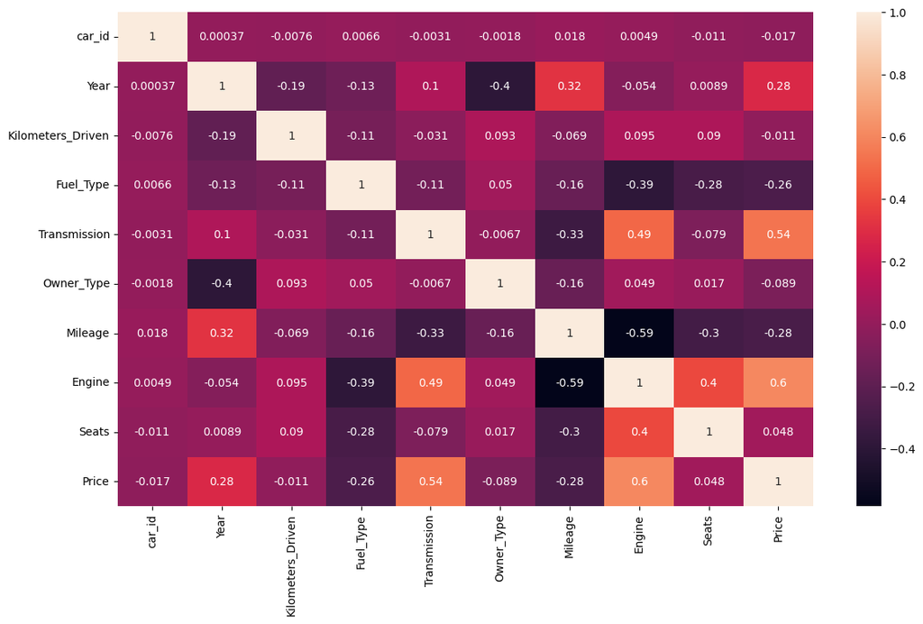

```python
plt.figure(figsize = (14, 8))
sns.heatmap(df1.corr(), annot = True)
plt.show()
```

this is a heatmap showing correlation between each and every column. as on ispecting we came to know that we have a positive correlation of price feature with the year,seats,engineand the transmission. and negetive correlation with the kilometers_driven,owner_type and mileage.

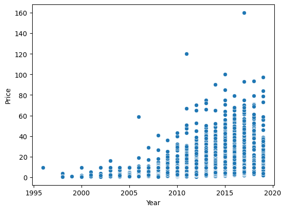

```python
sns.scatterplot(data = df1, x = 'Year', y = 'Price')
```

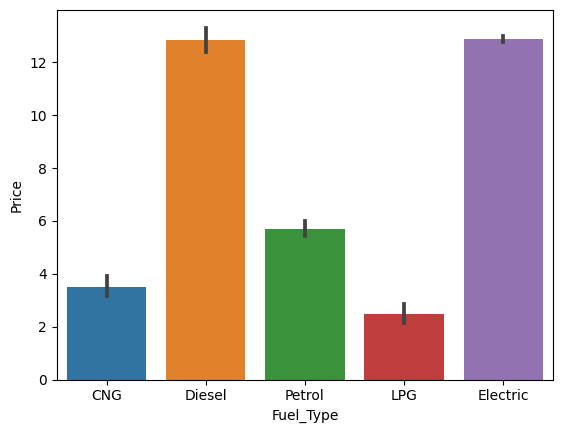

```python
sns.barplot(x="Fuel_Type",y="Price",data=df)
```

so, we can say that those vehicles in which fuel type is diesal or electric then these type of vehicles have greater price as compared of other.

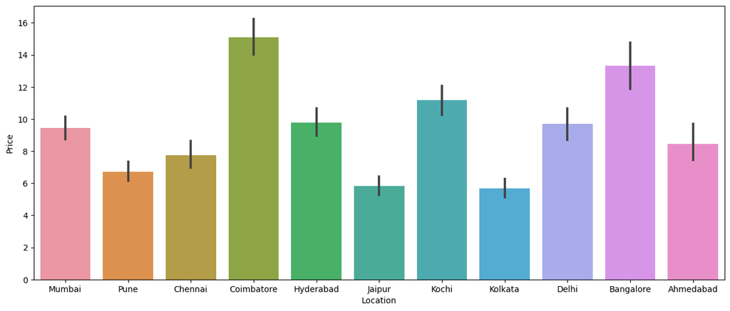

```python
plt.figure(figsize=(15,6))
sns.barplot(x="Location",y="Price", data=df)
```

so, cars in coimbatore and in banglore have higher prices as compared to other cities and the lowest prices are in the kolkata and in jaipur city.

```python
car_name=df1["Name"].apply(lambda row: row.split()[0])
car_name
```

```
0              Maruti
1             Hyundai
2               Honda
3              Maruti
4                Audi
            ...
7248       Volkswagen
7249       Volkswagen
7250           Nissan
7251       Volkswagen
7252    Mercedes-Benz
Name: Name, Length: 7253, dtype: object
```

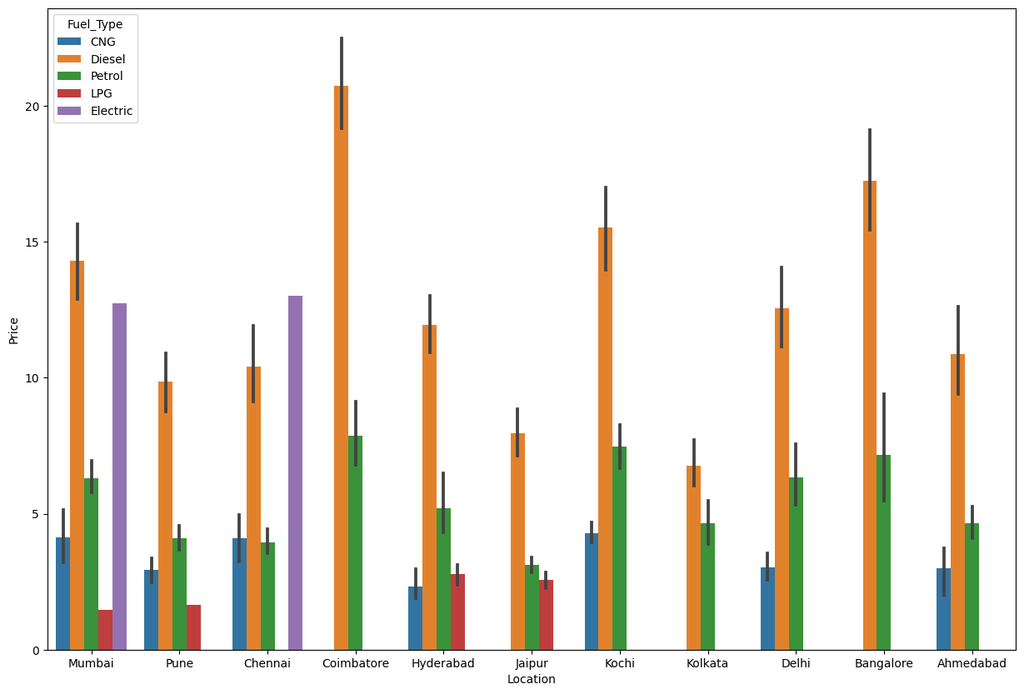

```python
plt.figure(figsize=(15,10))
sns.barplot(x="Location",y="Price",hue="Fuel_Type",data=df)
```

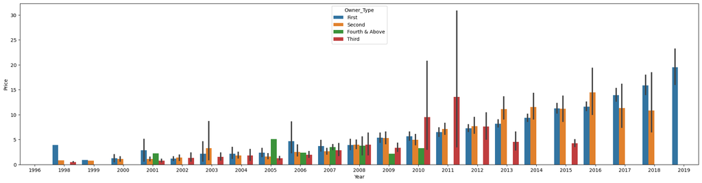

```python
plt.figure(figsize=(25,6))
sns.barplot(x="Year",y="Price",hue="Owner_Type",data=df)
```

so, as we look upon on the chart we can say that as the year increses the price keep on increasing but also the number of first owner type also incresing contineously.

```python
df1.info()
```

```
<class 'pandas.core.frame.DataFrame'>
RangeIndex: 7253 entries, 0 to 7252
Data columns (total 14 columns):
 #   Column             Non-Null Count  Dtype
---  ------             --------------  -----
 0   car_id             7253 non-null   int64
 1   Name               7253 non-null   object
 2   Location           7253 non-null   object
 3   Year               7253 non-null   int64
 4   Kilometers_Driven  7253 non-null   int64
 5   Fuel_Type          7253 non-null   int64
 6   Transmission       7253 non-null   int64
 7   Owner_Type         7253 non-null   int64
 8   Mileage            7253 non-null   float64
 9   Engine             7253 non-null   float64
 10  Power              7207 non-null   object
 11  Seats              7253 non-null   float64
 12  New_Price          1006 non-null   object
 13  Price              7253 non-null   float64
dtypes: float64(4), int64(6), object(4)
memory usage: 793.4+ KB
```

```python
from sklearn.model_selection import train_test_split
```

```python
y=df1["Engine"].values.reshape(-1,1)
y
```

```
array([[ 998.],
       [1582.],
       [1199.],
       ...,
       [1461.],
       [1197.],
       [2148.]])
```

```python
x=df1["Price"].values.reshape(-1,1)
x
```

```
array([[ 1.75],
       [12.5 ],
       [ 4.5 ],
       ...,
       [ 9.47],
       [ 9.47],
       [ 9.47]])
```

```python
x_train,x_test,y_train,y_test=train_test_split(x,y,test_size=0.3,random_state=42)
```

```python
x_train.shape
```

```
(5077, 1)
```

```python
x_test.shape
```

```
(2176, 1)
```

```python
y_train.shape
```

```
(5077, 1)
```

```python
y_test.shape
```

```
(2176, 1)
```

```python
from sklearn.linear_model import LinearRegression
```

```python
reg=LinearRegression()
```

```python
reg.fit(x_train,y_train)
```

```
LinearRegression()
```

```python
reg.intercept_
```

```
array([1294.38088318])
```

```python
reg.coef_
```

```
array([[34.38700511]])
```

```python
def a(slope,intercept,Engine):
    return slope*Engine + intercept
```

```python
b=a(reg.coef_,reg.intercept_,1197)
print(b)
```

```
[[42455.62600324]]
```

```python
y_pred=reg.predict(x_test)
```

```python
y_pred
```

```
array([[1466.31590875],
       [1620.0258216 ],
       [1620.0258216 ],
       ...,
       [1411.64057062],
       [1620.0258216 ],
       [1870.36321882]])
```

```python
df_pred=pd.DataFrame({"Engine":x_test.squeeze(),"actual":y_test.squeeze(),"Predicted":y_pred.squeeze()})
df_pred
```

[output not shown]

2176 rows × 3 columns

```python
from sklearn.metrics import mean_absolute_error,mean_squared_error,r2_score
```

```python
mae=mean_absolute_error(y_test,y_pred)
```

```python
mae
```

```
332.74008690667483
```

```python
mse=mean_squared_error(y_test,y_pred)
```

```python
mse
```

```
204347.90081975213
```

```python
rmse=np.sqrt(mse)
```

```python
rmse
```

```
452.0485602451933
```

```python
r2=r2_score(y_test,y_pred)
```

```python
r2
```

```
0.3925444891917228
```

so, here our mae i.e mean absolute error is 332.74

mae:= the mean absolute error is the diffrence between the predeiction and the true value of the observation i.e 0|Yi-Yi^|/n

mean squared error(mse)=: it measures how close a regression(straight) line is to a set of data point.

the worst part of the mse is it doubles i.e it square the outlires , so it is not robust to outliers.

root mean square (rmse) =: it basically measures for evaluating the quality of prediction . it shows how far predictions fall from measured true value.

r square (r2) =: it is the coefficient of determination.it basically evaluate the scattered data how much data is scattered

```python
df1
```

|  | car_id | Name | Location | Year | Kilometers_Driven | Fuel_Type | Transmission | Owner_Type | Mileage | Engine | Power | Seats | New_Price | Price |
| --- | --- | --- | --- | --- | --- | --- | --- | --- | --- | --- | --- | --- | --- | --- |
| 0 | 0 | Maruti Wagon R LXI CNG | Mumbai | 2010 | 72000 | 1 | 0 | 1 | 26.60 | 998.0 | 58.16 bhp | 5.0 | NaN | 1.75 |
| 1 | 1 | Hyundai Creta 1.6 CRDi SX Option | Pune | 2015 | 41000 | 2 | 0 | 1 | 19.67 | 1582.0 | 126.2 bhp | 5.0 | NaN | 12.50 |
| 2 | 2 | Honda Jazz V | Chennai | 2011 | 46000 | 3 | 0 | 1 | 18.20 | 1199.0 | 88.7 bhp | 5.0 | 8.61 Lakh | 4.50 |
| 3 | 3 | Maruti Ertiga VDI | Chennai | 2012 | 87000 | 2 | 0 | 1 | 20.77 | 1248.0 | 88.76 bhp | 7.0 | NaN | 6.00 |
| 4 | 4 | Audi A4 New 2.0 TDI Multitronic | Coimbatore | 2013 | 40670 | 2 | 1 | 2 | 15.20 | 1968.0 | 140.8 bhp | 5.0 | NaN | 17.74 |
| ... | ... | ... | ... | ... | ... | ... | ... | ... | ... | ... | ... | ... | ... | ... |
| 7248 | 1229 | Volkswagen Vento Diesel Trendline | Hyderabad | 2011 | 89411 | 2 | 0 | 1 | 20.54 | 1598.0 | 103.6 bhp | 5.0 | NaN | 9.47 |
| 7249 | 1230 | Volkswagen Polo GT TSI | Mumbai | 2015 | 59000 | 3 | 1 | 1 | 17.21 | 1197.0 | 103.6 bhp | 5.0 | NaN | 9.47 |
| 7250 | 1231 | Nissan Micra Diesel XV | Kolkata | 2012 | 28000 | 2 | 0 | 1 | 23.08 | 1461.0 | 63.1 bhp | 5.0 | NaN | 9.47 |
| 7251 | 1232 | Volkswagen Polo GT TSI | Pune | 2013 | 52262 | 3 | 1 | 3 | 17.20 | 1197.0 | 103.6 bhp | 5.0 | NaN | 9.47 |
| 7252 | 1233 | Mercedes-Benz E-Class 2009-2013 E 220 CDI Avan... | Kochi | 2014 | 72443 | 2 | 1 | 1 | 10.00 | 2148.0 | 170 bhp | 5.0 | NaN | 9.47 |

7253 rows × 14 columns

so, from the above analysis we can conclude that 1: milage is not the right factor for deciding the price of the cars.

4: people's are more intresting in buying 5 seater car.

7: the number of mannual car is greater than automatic.